# NIAID-1418 | Effect of instrument configuration on fluorochrome spectra

5L versus 6L | 63c, 83c filtered, and 90c

## Analysis objective

**Question 1.** When comparing 5L with 6L, do fluorochrome peak-detector assignments change?

**Question 2.** How different is each fluorochrome’s spectral signature between 5L and 6L?

The instrument configuration (**5L versus 6L**) is the comparison of interest. Each treatment (**Unfixed, 1% PFA, 4% PFA, Perm**) is analyzed **independently**; treatments are not compared with one another.

The three experimental datasets are shown side by side: **63c**, **83c filtered**, and **90c**. The 83c results use the filtered fluorochrome set.

The analysis compares **5L versus 6L** for each fluorochrome. **Instrument configuration is the independent comparison**; Unfixed, 1% PFA, 4% PFA, and Perm are analyzed and displayed **separately**, without comparing treatments to one another.

**Are there changes in the peaks?** Yes. The overall peak-detector assignment changes for some fluorochromes. The analysis also reports whether peak assignments agree when restricted to detectors shared by 5L and 6L, because 6L includes an additional detector block.

**How different are the spectral signatures?** This is quantified for each matched fluorochrome using **cosine similarity** (spectral shape) and **normalized RMSE** (pointwise spectral difference) on the shared detector set. Distributions and selected spectral overlays show the results separately for each treatment.

## 1. Do peak-detector assignments change between 5L and 6L?

For each fluorochrome within each treatment, compare the detector containing the maximum signal in the 5L and 6L configurations. Where reported, distinguish the **overall maximum** from the maximum restricted to **detectors shared by both configurations**.

**Reported results.** In 63c, overall peak agreement was approximately **58.9–60.7%**, versus **98.2–100%** on shared detectors. For filtered 83c and 90c, peak agreement was generally around **97–100%**. These are two distinct peak-assignment measures.

**63c**

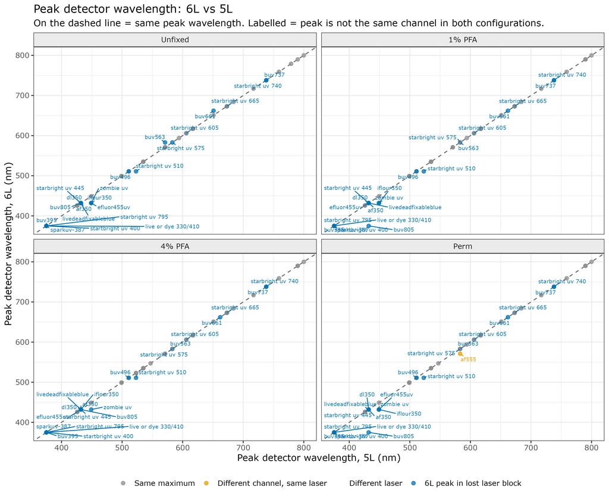

**83c filtered**

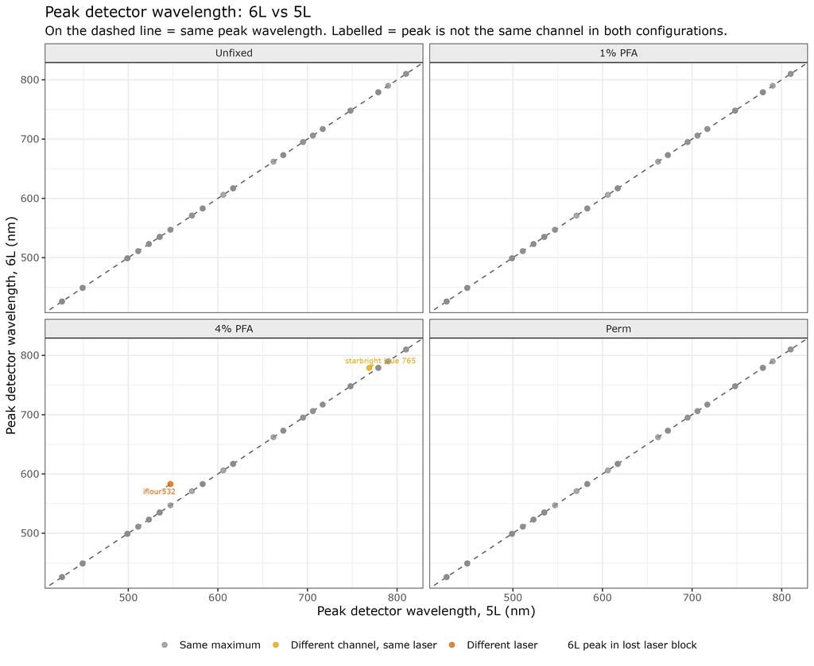

**90c**

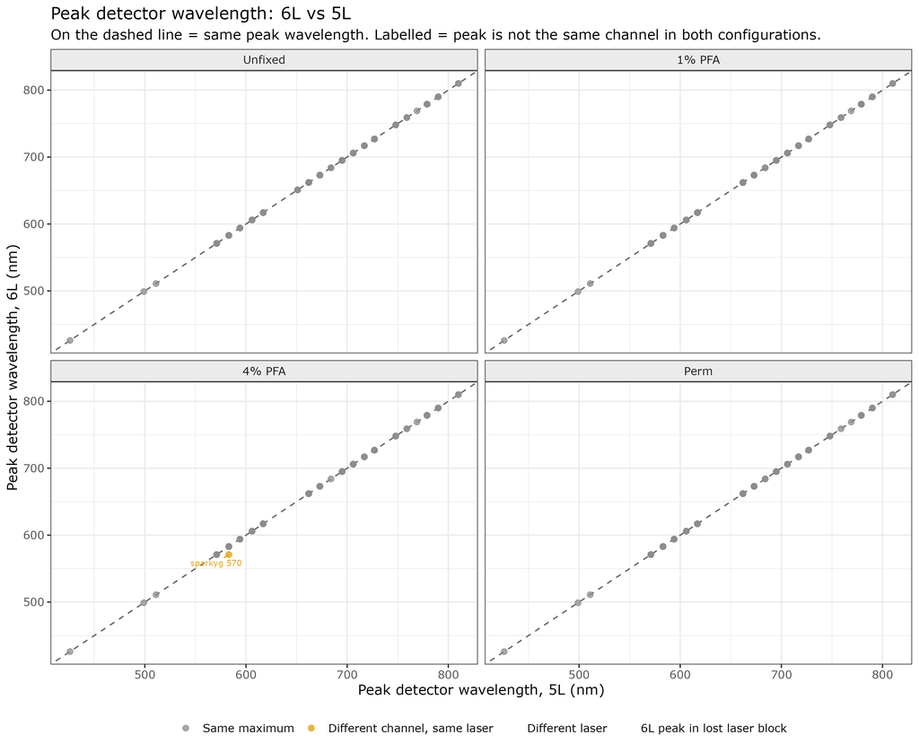

## 2. How different are the 5L and 6L spectral signatures?

Compare the normalized spectral profiles of the same fluorochrome measured in the two configurations, using **shared active detectors** for spectral-shape metrics. The 6L-only detector block is not treated as a directly comparable 5L measurement.

**Cosine similarity** measures agreement in normalized spectral shape (1 indicates identical direction of the compared vectors). **Normalized RMSE** summarizes the magnitude of pointwise differences on the normalized scale (smaller values indicate closer agreement).

**Reported results.** Median cosine similarities exceed **0.99995** across the dataset-by-treatment groups. Cosine similarity and RMSE are reported separately for each treatment, with no cross-treatment contrast.

### 2a. Cosine similarity

The reported group medians exceed **0.99995**. The minimum cosine values in 63c were approximately **0.9578 (Unfixed), 0.9055 (1% PFA), 0.9345 (4% PFA), and 0.9770 (Perm)**. Filtered 83c minima were approximately **0.9987, 0.9999, 0.9994, and 0.9997**, respectively. The 90c **1% PFA** group included an observation near **0.9696**. These are individual extremes, not group averages.

**63c**

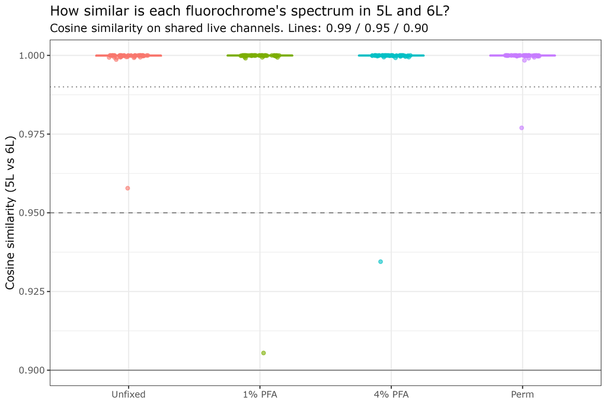

**83c filtered**

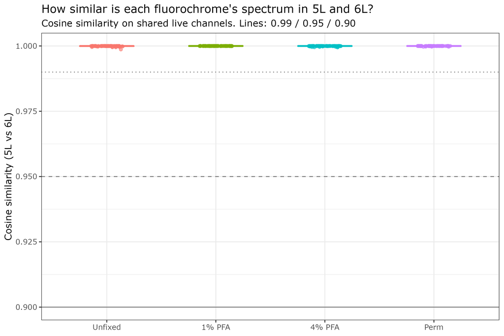

**90c**

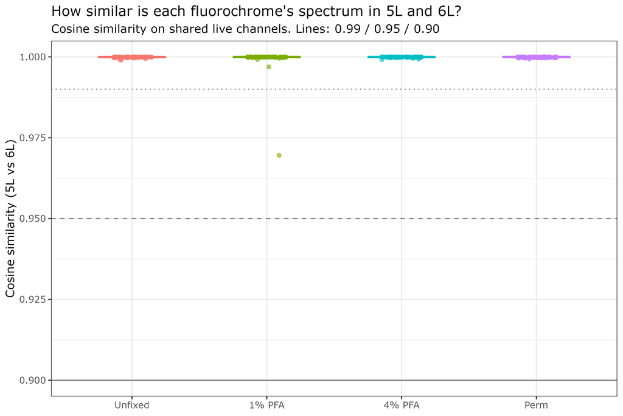

### 2b. Normalized RMSE

**Reported results.** Median normalized RMSE values were approximately **0.00087–0.00179** across groups. Smaller RMSE indicates a smaller difference between the aligned, normalized spectral vectors.

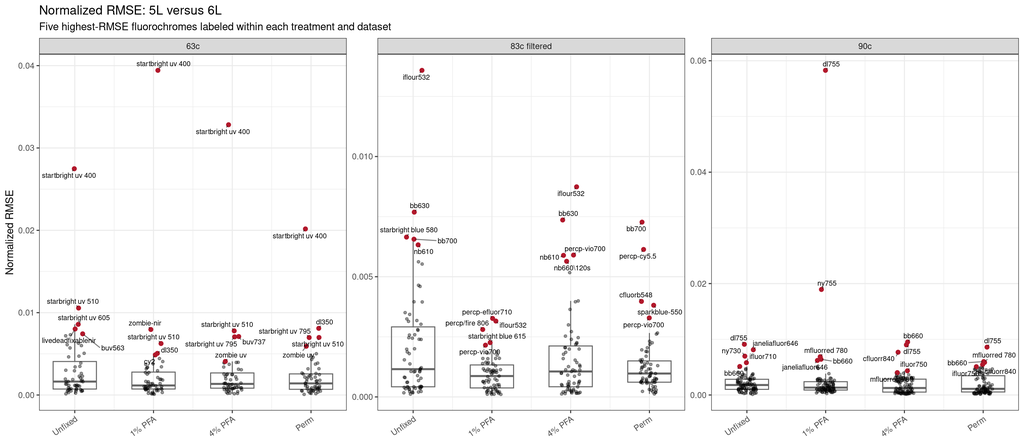

### 2c. Fluorochromes with the lowest spectral similarity

The plots identify fluorochromes with the lowest cosine similarity **within each dataset and treatment**. The selected fluorochromes can differ among panels.

**Analysis displayed.** Fluorochromes are ranked by their 5L–6L cosine similarity within each dataset and treatment. The displayed lowest-similarity fluorochromes are selected independently for each group.

**63c**

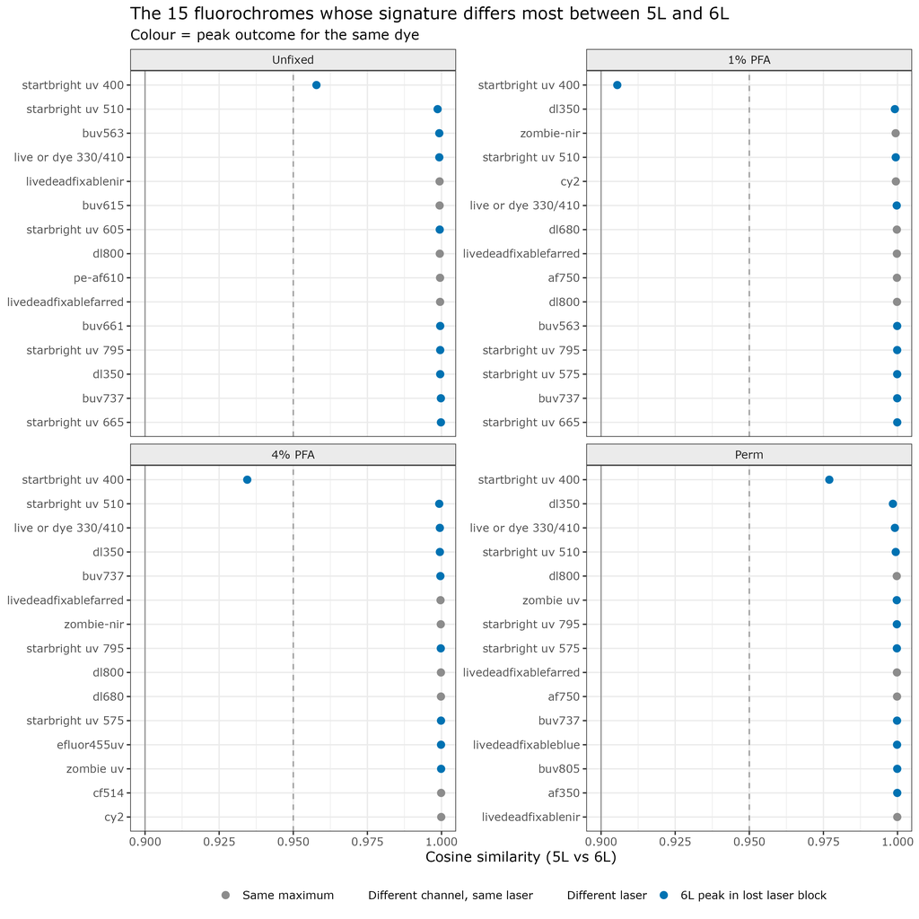

**83c filtered**

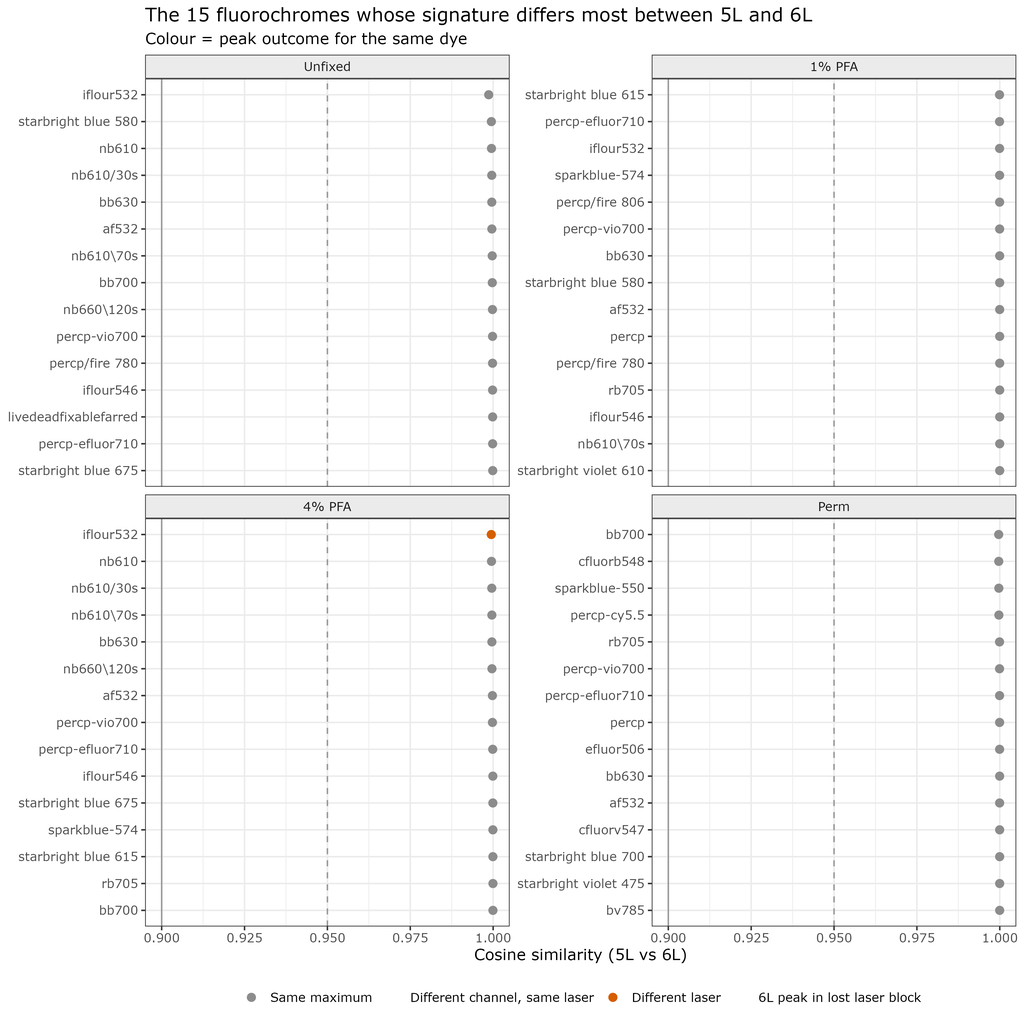

**90c**

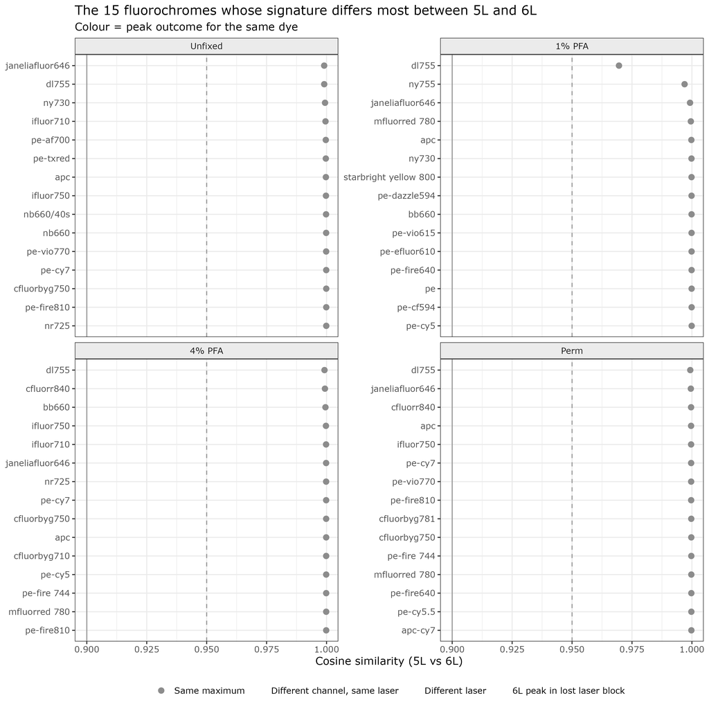

## 3. Spectral overlays: independent analysis for each treatment

The 5L and 6L spectral profiles are overlaid for the six lowest-cosine fluorochromes in each dataset, separately for each treatment. These are **within-treatment configuration comparisons**, not comparisons among treatments.

### Unfixed

**63c**

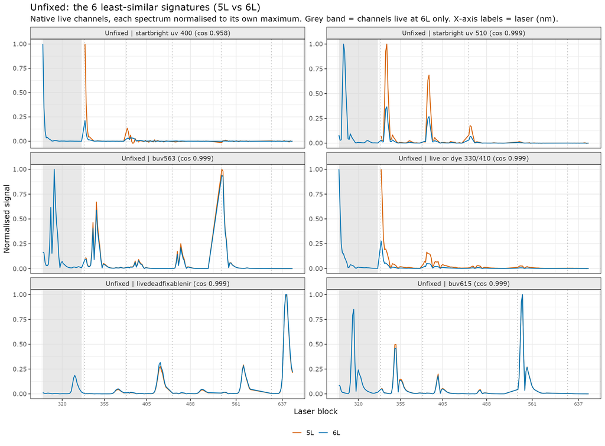

**83c filtered**

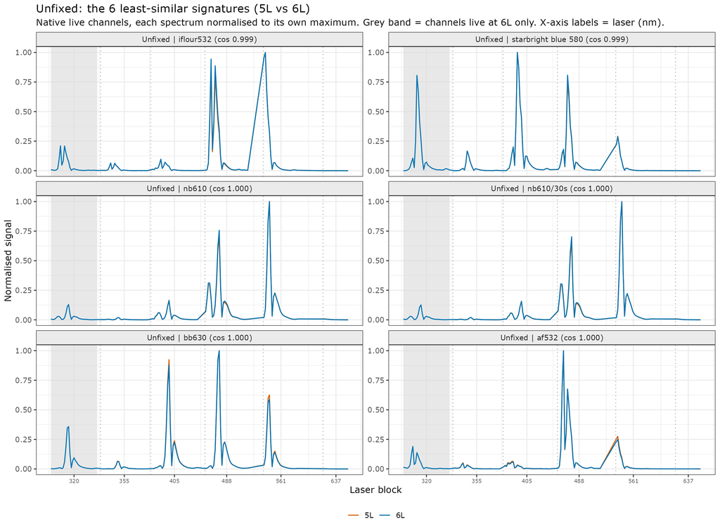

**90c**

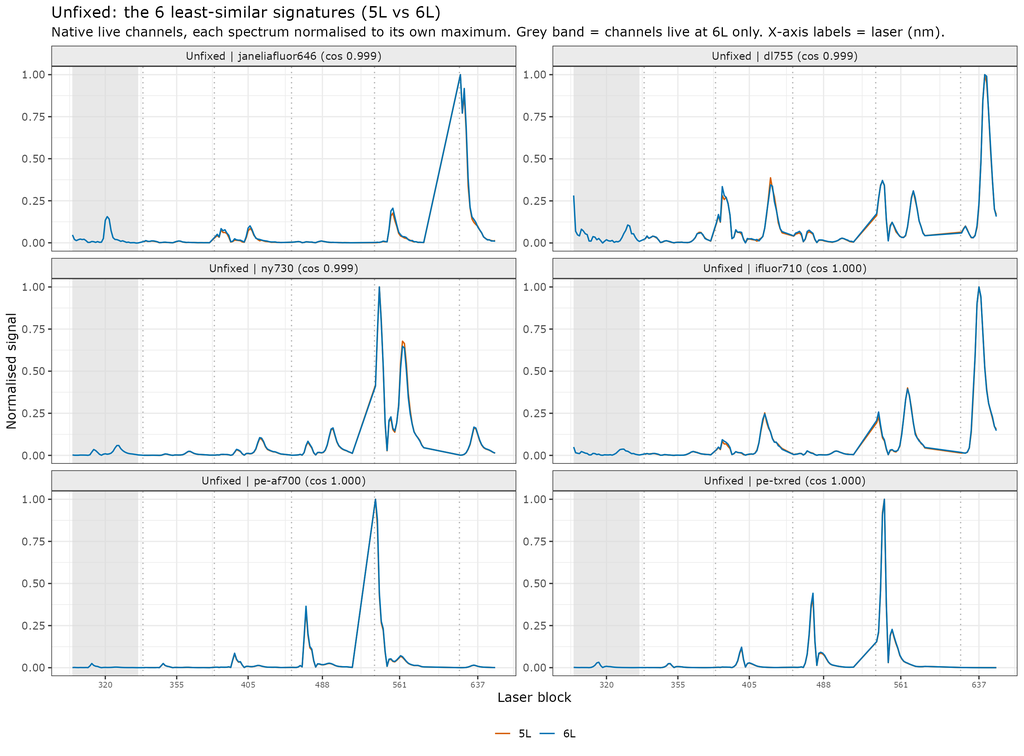

### 1% PFA

**63c**

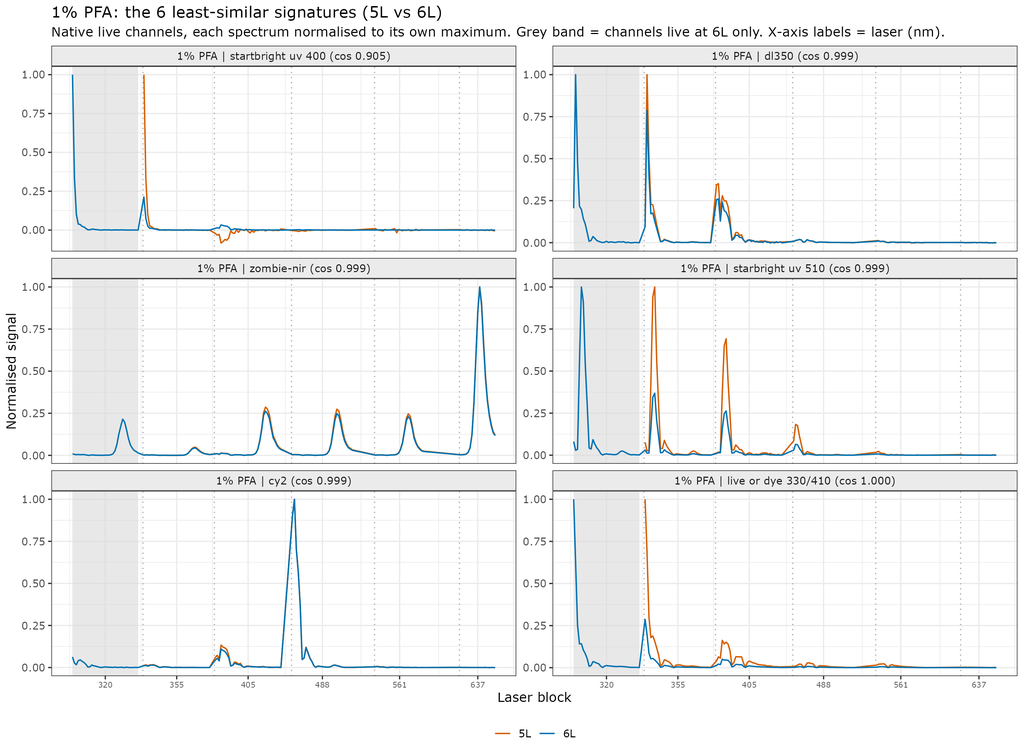

**83c filtered**

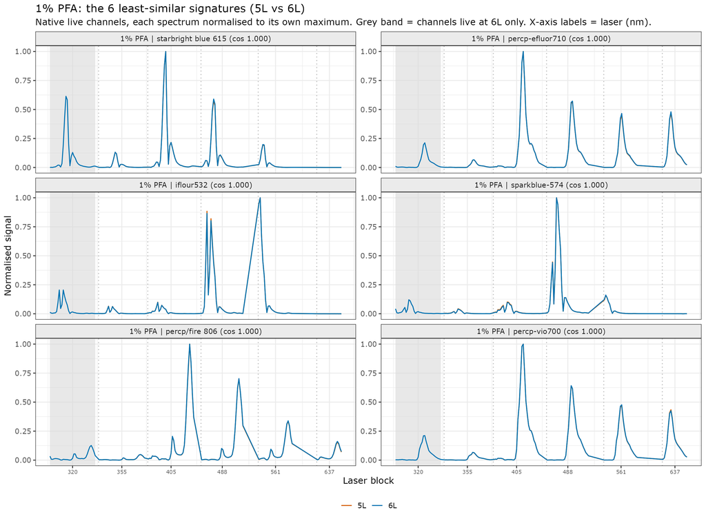

**90c**

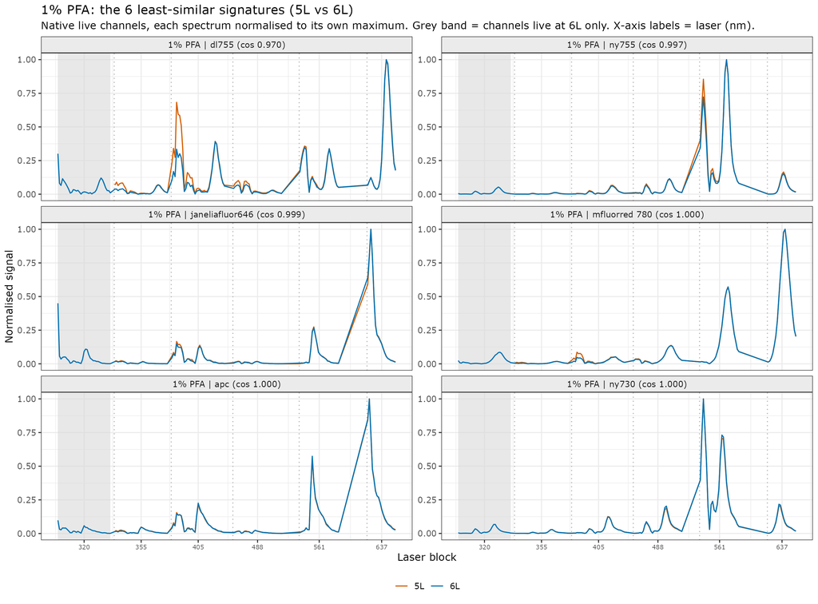

### 4% PFA

**63c**

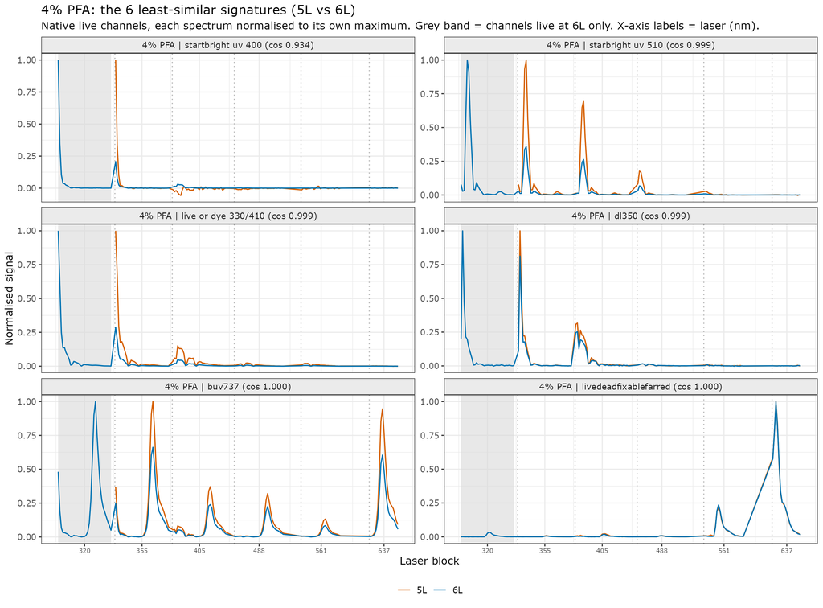

**83c filtered**

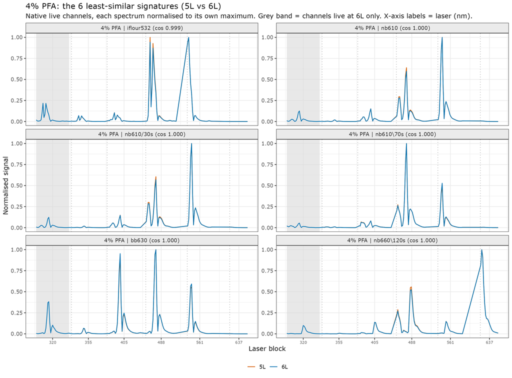

**90c**

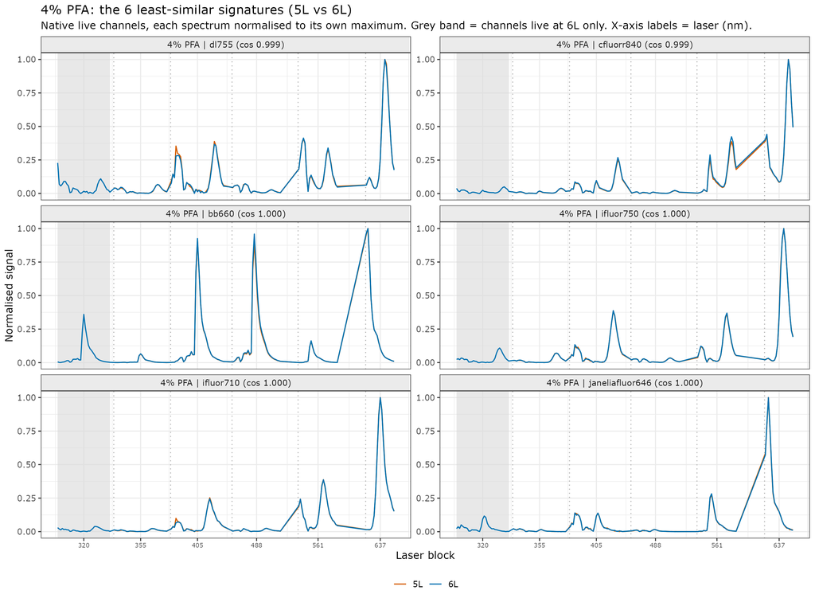

### Perm

**63c**

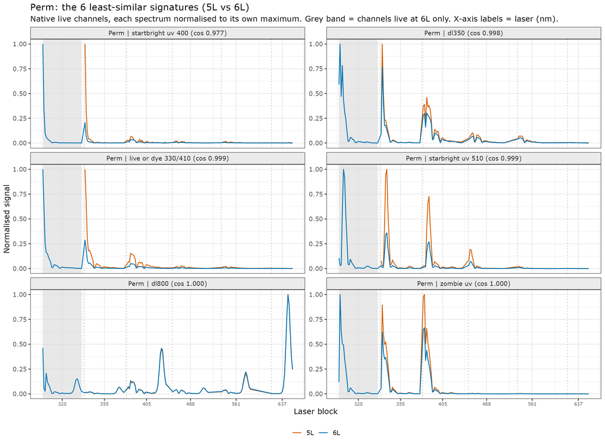

**83c filtered**

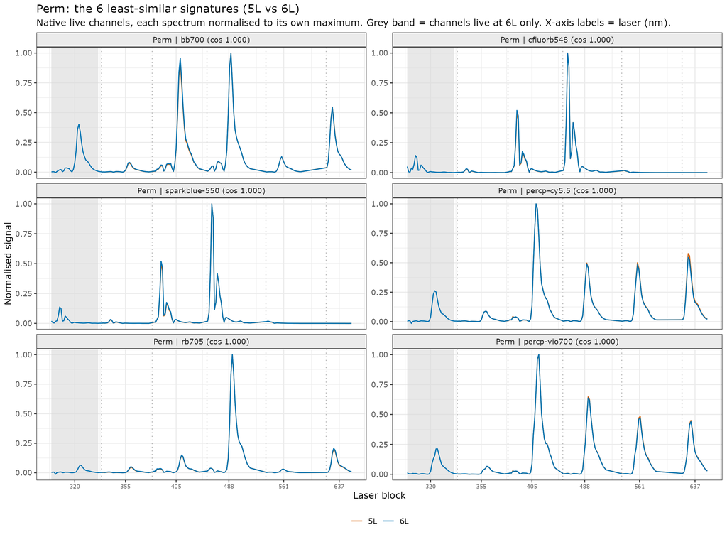

**90c**

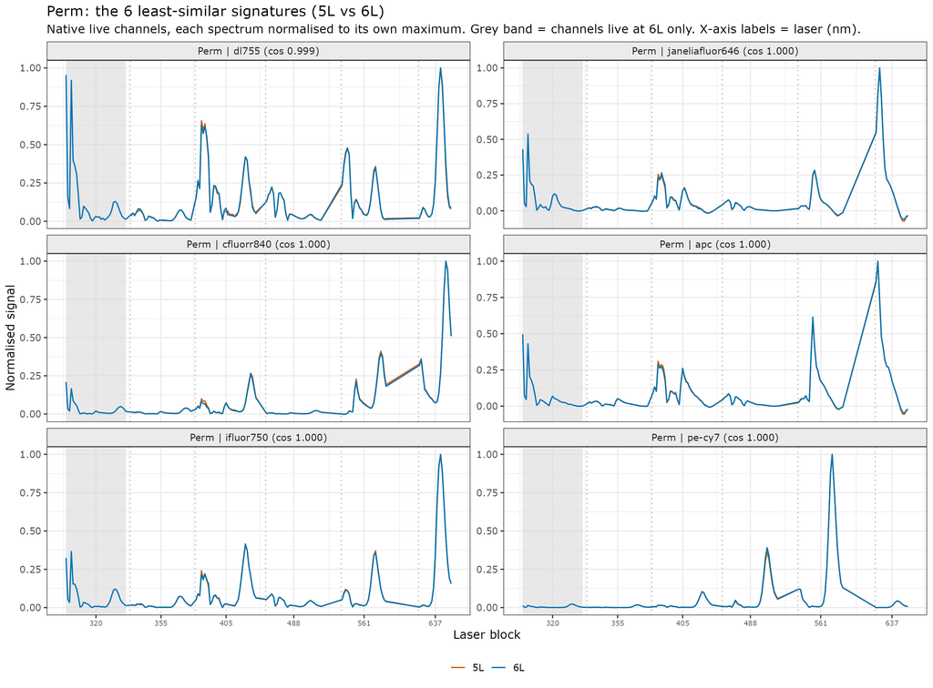

## 4. Spectral overlays for peak-detector changes

All **same-laser, different-detector** cases (orange) and **different-laser** cases (red) are shown below, as identified directly from the upstream analysis tables. One 63c example from the **6L peak in lost laser block** category (blue) is also shown. These cases are selected by peak-change classification, **not** by cosine similarity rank. Spectra compare 5L and 6L under the same treatment.

### 63c

#### Perm | af555

Different channel, same laser; peak detector: 5L 561-583 to 6L 561-571.

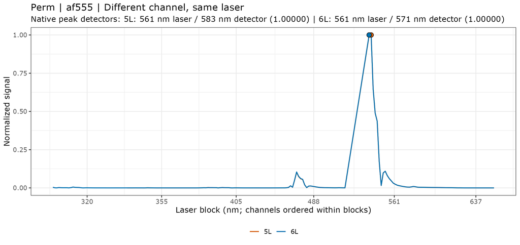

**Peak-detector detail (zoom)**

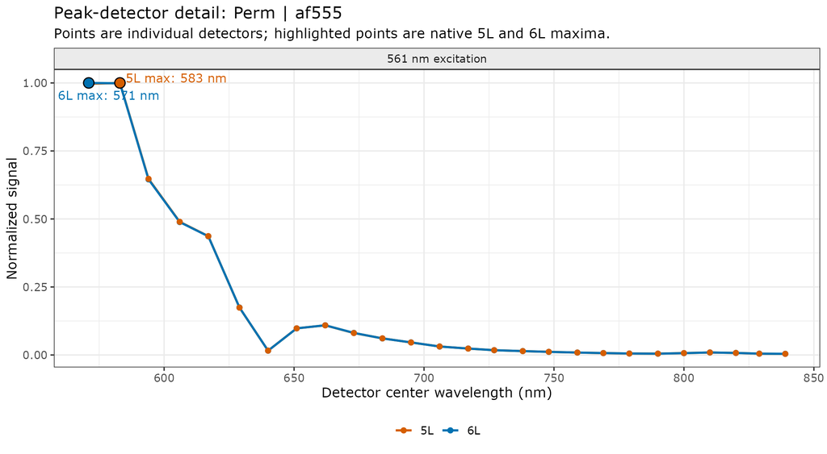

#### Unfixed | af350

6L peak in lost laser block; peak detector: 5L 355-432 to 6L 320-432.

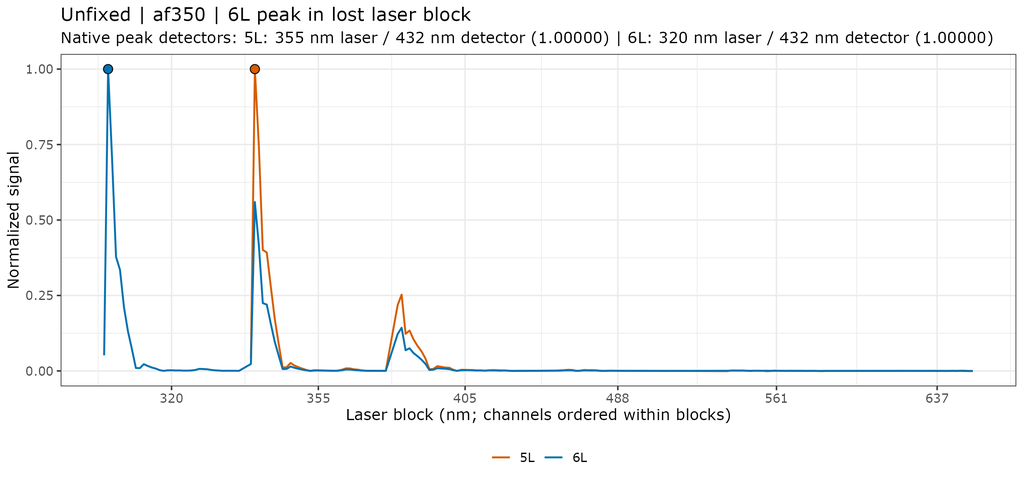

**Peak-detector detail (zoom)**

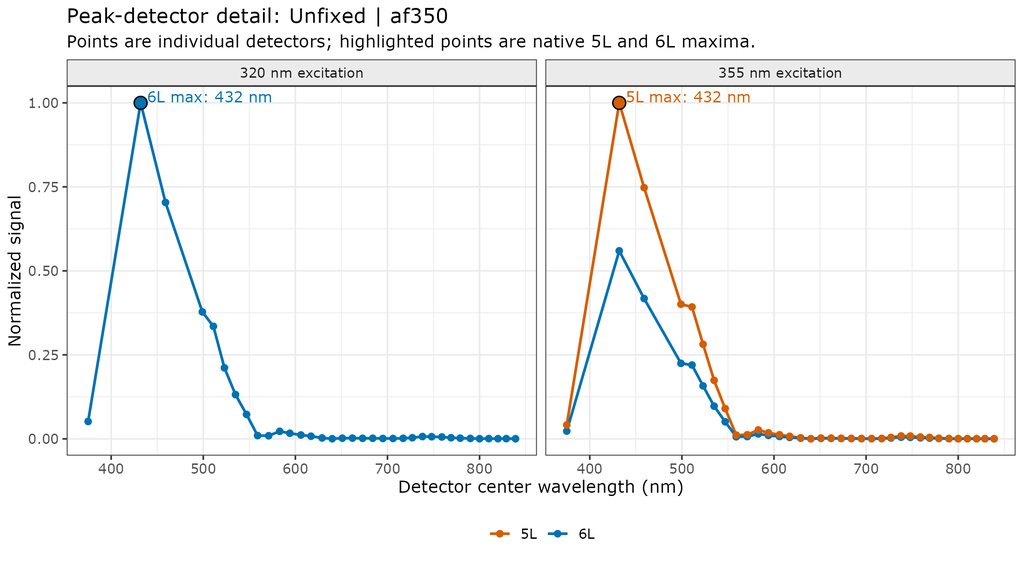

### 83c filtered

#### 4% PFA | iflour532

Different laser; peak detector: 5L 488-547 to 6L 561-583.

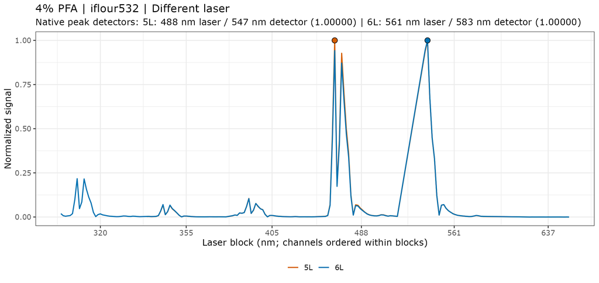

**Peak-detector detail (zoom)**

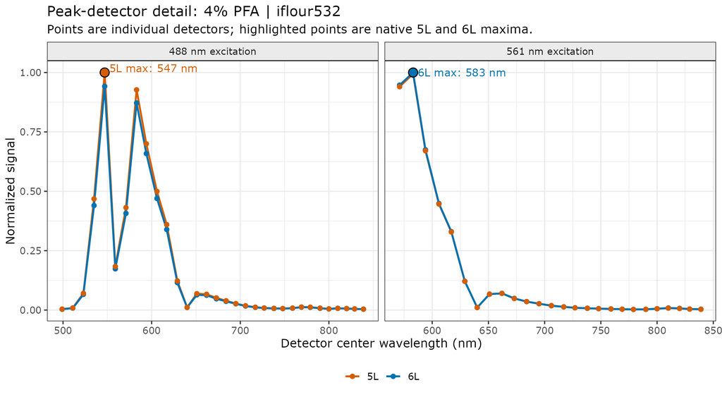

#### 4% PFA | starbright blue 765

Different channel, same laser; peak detector: 5L 405-769 to 6L 405-779.

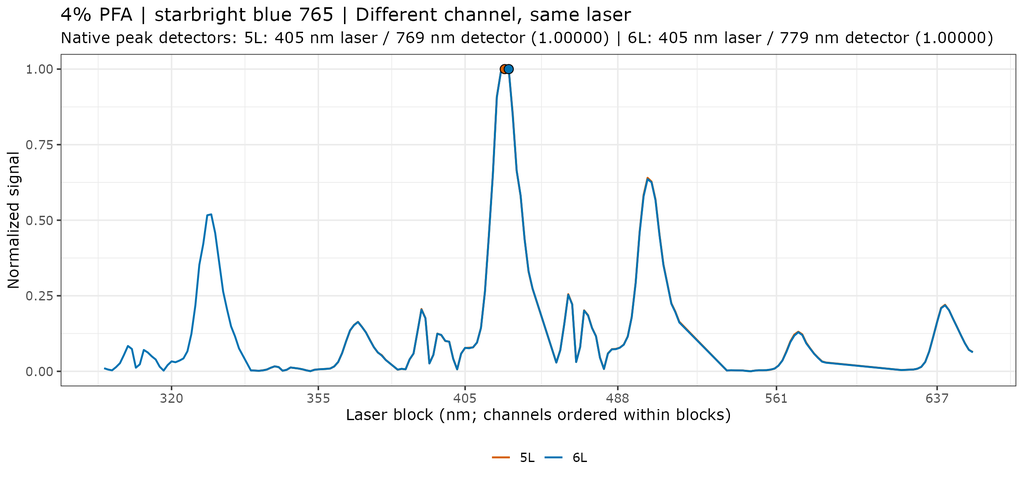

**Peak-detector detail (zoom)**

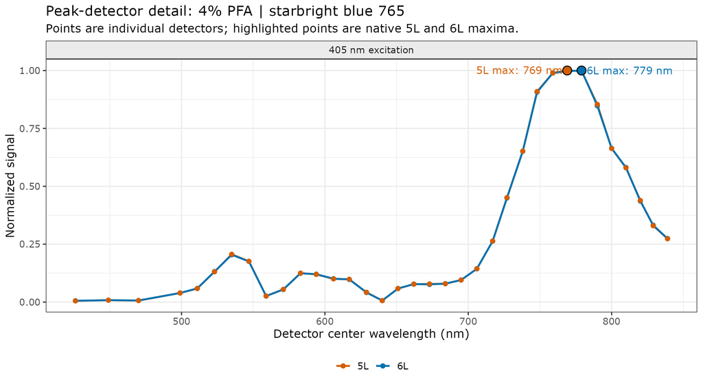

### 90c

#### 4% PFA | sparkyg 570

Different channel, same laser; peak detector: 5L 561-583 to 6L 561-571.

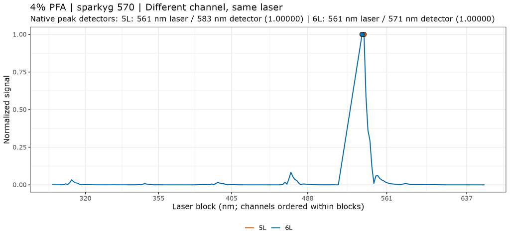

**Peak-detector detail (zoom)**

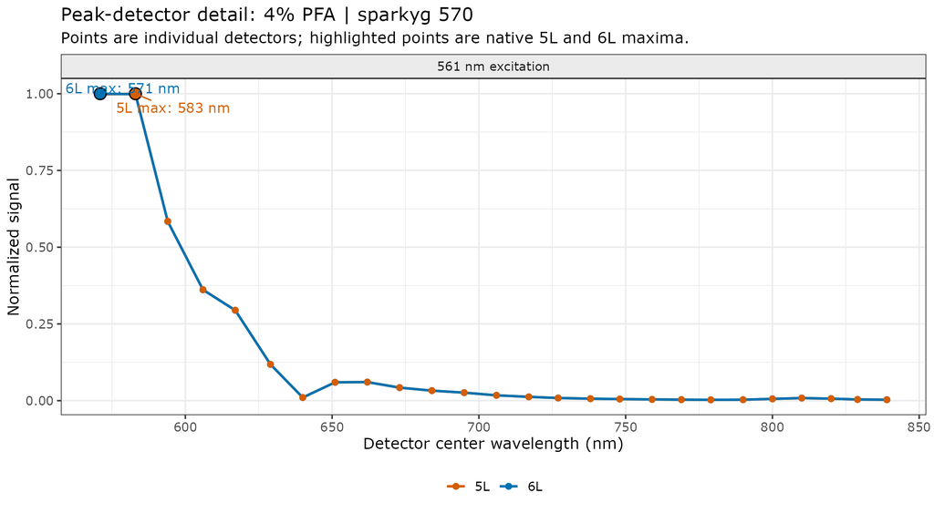

## Appendix A. Methods

### A1. Experimental comparison and analysis unit

Three independently supplied fluorochrome collections were analyzed: **63c**, **83c filtered**, and **90c**. For each collection, 5-laser (**5L**) and 6-laser (**6L**) spectral measurements were compared **within the same fluorochrome and preparation condition**. The conditions were Unfixed, 1% PFA, 4% PFA, and Perm. No cross-treatment pairing was used to calculate the 5L–6L metrics.

### A2. Spectral data alignment and detector selection

Spectral measurements were organized by fluorochrome, treatment, instrument configuration, and detector/channel. Detector identifiers were aligned between configurations before comparison. Because 6L has an additional 320-nm deep-UV detector block, **shared-detector comparisons were restricted to channels active in both configurations**. Channels exclusive to 6L were not treated as zeros or missing observations from 5L for cosine or RMSE calculations. Overall peak assignments, by contrast, could include configuration-specific detectors and were therefore reported separately.

### A3. Peak-detector concordance

For each fluorochrome-treatment record, the detector with the largest measured signal was identified independently in 5L and 6L. Two outcomes were distinguished: (i) **overall-maximum agreement**, using the detector set available to each configuration; and (ii) **shared-channel peak agreement**, restricting both configurations to the common detector set. Agreement percentages summarize the fraction of evaluable fluorochrome-treatment records for which the peak detector matched. The two percentages should not be interchanged.

### A4. Spectral similarity

For each matched fluorochrome-treatment pair, the two spectral intensity vectors were aligned to the same shared active detectors and normalized according to the underlying analysis pipeline. Cosine similarity was calculated.

### A5. Summaries, outliers, and spectral overlays

Metrics were summarized separately by dataset and treatment. Distributions describe typical behavior, while the minimum cosine similarity highlights the most discordant observations. The **six lowest-cosine fluorochromes** were selected independently within each dataset-treatment group for overlay visualization. Because fluorochrome identities may differ, these are **within-group diagnostic rankings**, not a matched-dye comparison across experiments.

### A6. Quality control and 83c exclusions

The collaborator identified **16 potentially problematic fluorochromes in 83c** for review. The presented 83c analysis uses the filtered dataset, with the flagged outliers excluded upstream. The filtered results must therefore be interpreted as conditional on that exclusion. The exclusion list, selection rationale, and unfiltered-versus-filtered sensitivity analysis should be retained with the source data for full reproducibility.

### A7. Peak-shift case-study selection

All highlighted orange and red peak-shift cases from the supplied peak-assignment plots were selected for per-fluorochrome inspection. A single blue example was chosen to illustrate the category in which the 6L maximum occurs in a detector block absent from 5L. Each requested overlay must be generated from the corresponding matched 5L and 6L source spectra under the same treatment. These examples are descriptive and were not selected using the lowest-cosine ranking.

### A8. Peak annotations and detector-level zoom

For each selected fluorochrome and treatment, the native maximum was identified separately for 5L and 6L using active detectors. The plots mark both maxima, report their excitation-laser and detector-center wavelengths, and display normalized signal at each maximum. A companion zoom plot uses detector-center wavelength on the horizontal axis and focuses on the excitation-laser block(s) containing the maxima. These plots are descriptive; normalization does not permit inference about absolute brightness.